# Assessment 0

## Introduction

In the following code we analyse COVID-19 hospitalisation data within the UK and across the world. We aim to look for any relations between the data through the code we find, and seeing how we can improve our findings to give us more insight into how the global pandemic affected healthcare facilities worldwide.

The following pre-requisites are required:

```r
library(ggplot2)
library(dplyr)
library(reshape2)
library(lubridate)
library(tidyr)
```

## Instructions for Importing the Dataset

1. The first dataset is here: https://ourworldindata.org/covid-hospitalizations
2. You can find a link to the CSV file on Our World in Data’s GitHub here, called ‘covid-hospitalizations.csv’: https://github.com/owid/covid-19-data/tree/master/public/data/hospitalizations
3. Save this file to your desired location, under the file-name ‘covid-hospitalizations.csv’

## Exploratory Data Analaysis

### A brief look

In this section we will complete an first analysis to see how different countries across the world coped.

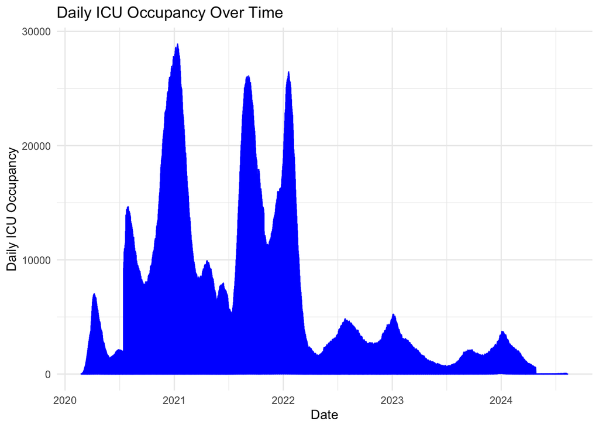

```r
# Read the dataset
data <- read.csv("/Users/harrywilson/Desktop/DataScienceToolbox/DataSets/covid-hospitalizations.csv")

# Select only the relevant columns
data$date <- as.Date(data$date)
icu_data <- data %>%
    filter(indicator == "Daily ICU occupancy") %>%
    select(date, value)

# Make the plot
ggplot(icu_data, aes(x = date, y = value)) +
    geom_line(color = "blue") +
    labs(title = "Daily ICU Occupancy Over Time",
         x = "Date",
         y = "Daily ICU Occupancy") +
    theme_minimal()
```

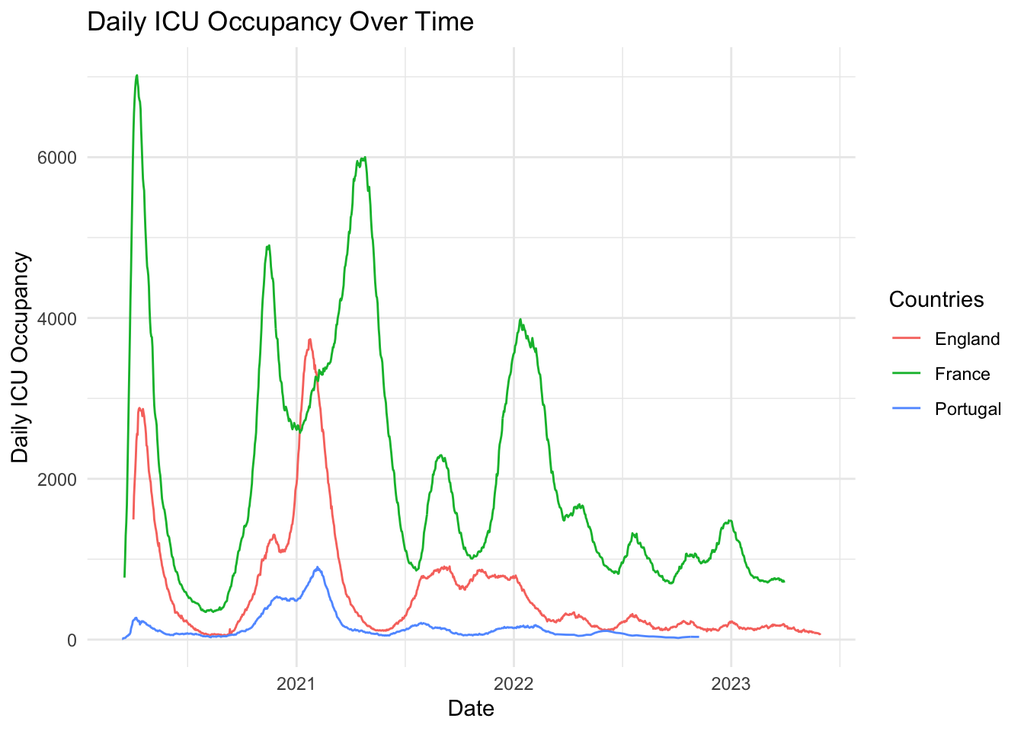

```r
# Read the dataset
data <- read.csv("/Users/harrywilson/Desktop/DataScienceToolbox/DataSets/covid-hospitalizations.csv")

# Convert date column to Date type
data$date <- as.Date(data$date)

# Select only relevant columns and filter for specific locations
selected_locations <- c("England", "France", "Portugal")

icu_data <- data %>%
    filter(indicator == "Daily ICU occupancy", entity %in% selected_locations) %>%
    select(date, entity, value)

# Make the plot
ggplot(icu_data, aes(x = date, y = value, color = entity)) +
    geom_line() +
    labs(title = "Daily ICU Occupancy Over Time",
         x = "Date",
         y = "Daily ICU Occupancy",
         color = "Countries")+
    theme_minimal()
```

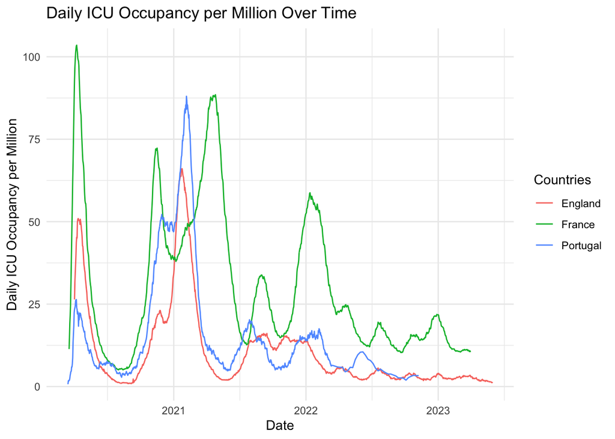

```r
# Read the dataset
data <- read.csv("/Users/harrywilson/Desktop/DataScienceToolbox/DataSets/covid-hospitalizations.csv")

# Convert date column to Date type
data$date <- as.Date(data$date)

# Select only relevant columns and filter for specific locations
selected_locations <- c("England", "France", "Portugal")

icu_data <- data %>%
    filter(indicator == "Daily ICU occupancy per million", entity %in% selected_locations) %>%
    select(date, entity, value)

# Make the plot
ggplot(icu_data, aes(x = date, y = value, color = entity)) +
    geom_line() +
    labs(title = "Daily ICU Occupancy per Million Over Time",
         x = "Date",
         y = "Daily ICU Occupancy per Million",
         color = "Countries") +
    theme_minimal()
```

We can see that each of the countries, France initially struggled the most, doubling Englands ICU occupancy per million. This shows how much of a strain they were under. We see England coped okay relatively, however Portugal was also put under a lot of strain in early 2021.

### Looking in more depth

We will look at the different countries we can analyse in this dataset, along with what there is to analyse in the set.

```r
unique_locations <- unique(data$entity)
print(unique_locations)
```

```
##  [1] "Algeria"          "Argentina"        "Australia"        "Austria"
##  [5] "Belgium"          "Bolivia"          "Bulgaria"         "Canada"
##  [9] "Chile"            "Croatia"          "Cyprus"           "Czechia"
## [13] "Denmark"          "England"          "Estonia"          "Finland"
## [17] "France"           "Germany"          "Greece"           "Hungary"
## [21] "Iceland"          "Ireland"          "Israel"           "Italy"
## [25] "Japan"            "Latvia"           "Liechtenstein"    "Lithuania"
## [29] "Luxembourg"       "Malaysia"         "Malta"            "Netherlands"
## [33] "Northern Ireland" "Norway"           "Poland"           "Portugal"
## [37] "Romania"          "Scotland"         "Serbia"           "Singapore"
## [41] "Slovakia"         "Slovenia"         "South Africa"     "South Korea"
## [45] "Spain"            "Sweden"           "Switzerland"      "United Kingdom"
## [49] "United States"    "Wales"
```

```r
unique_indicators <- unique(data$indicator)
print(unique_indicators)
```

```
## [1] "Daily ICU occupancy"
## [2] "Daily ICU occupancy per million"
## [3] "Daily hospital occupancy"
## [4] "Daily hospital occupancy per million"
## [5] "Weekly new hospital admissions"
## [6] "Weekly new hospital admissions per million"
## [7] "Weekly new ICU admissions"
## [8] "Weekly new ICU admissions per million"
```

Here, we will explore if there is any relation between Daily ICU Occupancy and Daily Hospital Occupancy in England. First, we start off with a basic heat map to see if our hypothesis, that they will be correlated, seems to be correct.

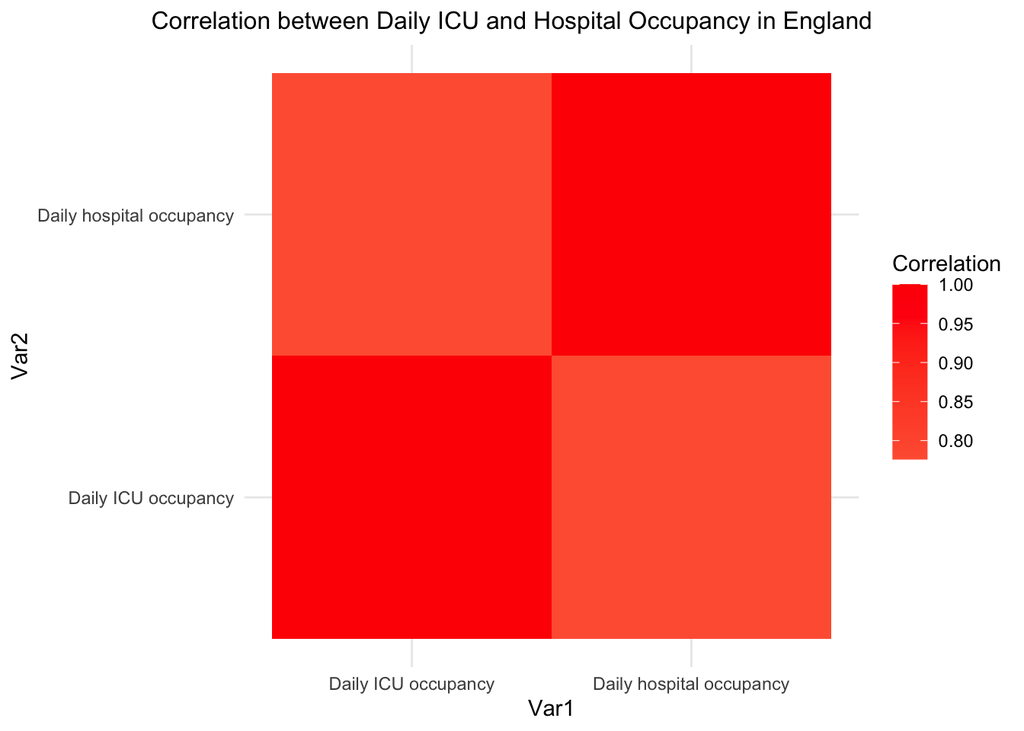

```r
# Filter for 'England' and for the relevant indicators
england_data <- data %>%
    filter(entity == "England",
           indicator %in% c("Daily ICU occupancy", "Daily hospital occupancy"))

# Reshape the data for correlation calculation
england_wide <- england_data %>%
    pivot_wider(names_from = indicator, values_from = value)

# Calculate correlation matrix
cor_matrix <- cor(england_wide[, c("Daily ICU occupancy", "Daily hospital occupancy")], use = "complete.obs")

# Melt the correlation matrix to long format for heatmap plotting
cor_melt <- melt(cor_matrix)

# Plot heatmap
ggplot(cor_melt, aes(Var1, Var2, fill = value)) +
    geom_tile() +
    scale_fill_gradient2(low = "blue", high = "red", mid = "white", midpoint = 0) +
    labs(title = "Correlation between Daily ICU and Hospital Occupancy in England",
         fill = "Correlation") +
    theme_minimal() +
    theme(plot.title = element_text(size = 12, hjust = 0.5),
          plot.title.position = "plot")
```

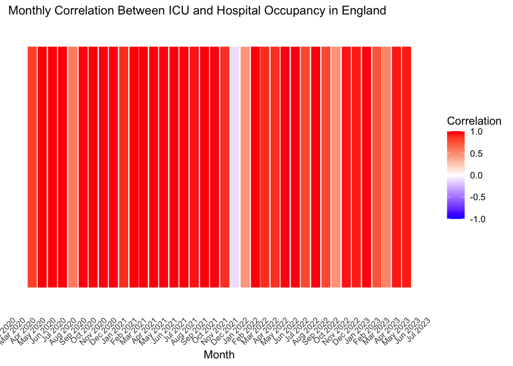

```r
# Convert date column to Date type if not already done
data$date <- as.Date(data$date)

# Filter the data for 'England' and the relevant indicators
data_filtered <- data %>%
    filter(entity == "England",
           indicator %in% c("Daily ICU occupancy", "Daily hospital occupancy")) %>%
    select(entity, date, indicator, value)

# Aggregate data by month to reduce overcrowding
data_filtered <- data_filtered %>%
    mutate(month = floor_date(date, "month"))

# Pivot data to wide format to have ICU and hospital occupancy in separate columns
data_wide <- data_filtered %>%
    pivot_wider(names_from = indicator, values_from = value)

# Remove rows with missing values
data_wide <- na.omit(data_wide)

# Calculate the correlation between ICU occupancy and hospital occupancy for each month
monthly_corr <- data_wide %>%
    group_by(month) %>%
    summarise(correlation = cor(`Daily ICU occupancy`, `Daily hospital occupancy`, use = "complete.obs"))

# Create the heatmap
ggplot(monthly_corr, aes(x = month, y = 1, fill = correlation)) +
    geom_tile(color = "white") +
    scale_fill_gradient2(low = "blue", mid = "white", high = "red", midpoint = 0, limits = c(-1,1),name = "Correlation") +
    labs(title = "Monthly Correlation Between ICU and Hospital Occupancy in England",
         x = "Month",
         y = "",
         fill = "Correlation") +
    theme_minimal() +
    theme(axis.text.y = element_blank(),
          axis.ticks.y = element_blank(),
          panel.grid.major = element_blank(),
          panel.grid.minor = element_blank(),
          axis.title.y = element_blank(),
          axis.text.x = element_text(size = 8, angle = 45, hjust = 1),  # Smaller x-axis text
          plot.title = element_text(size = 12)) +  # Adjust title size
    scale_x_date(date_labels = "%b %Y", date_breaks = "1 month") +
    scale_y_discrete(limits = c("Correlation"))  # Ensure y-axis is labeled properly
```

From this, we see that there is a clear correlation throughout the pandemic, however it looks like there is no correlation in one of the months. We are unsure of the reason of this, so we take a look at all data included, along with missing data to see if this tells us anything.

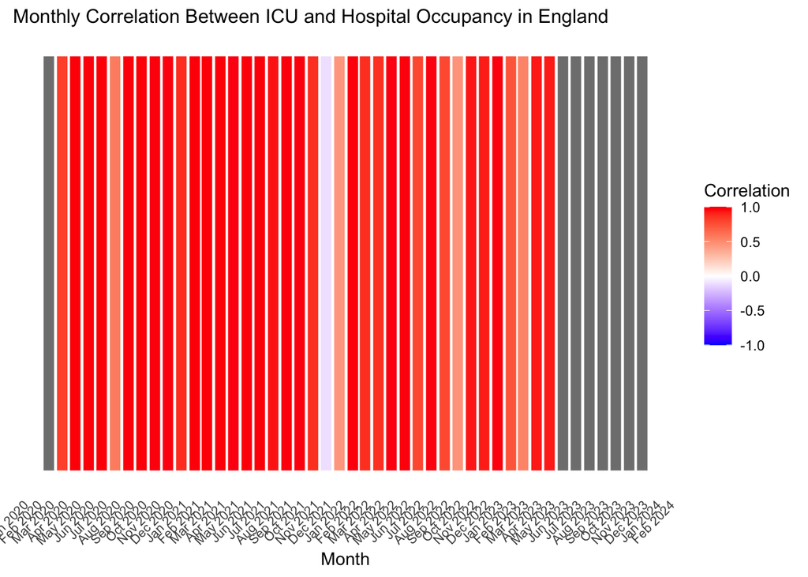

```r
# Convert date column to Date type if not already done
data$date <- as.Date(data$date)

# Filter the data for 'England' and the relevant indicators
data_filtered <- data %>%
    filter(entity == "England",
           indicator %in% c("Daily ICU occupancy", "Daily hospital occupancy")) %>%
    select(entity, date, indicator, value)

# Aggregate data by month
data_filtered <- data_filtered %>%
    mutate(month = floor_date(date, "month"))

# Pivot data to wide format
data_wide <- data_filtered %>%
    pivot_wider(names_from = indicator, values_from = value)

# Remove rows with missing values
data_wide <- na.omit(data_wide)

# Calculate the correlation
monthly_corr <- data_wide %>%
    group_by(month) %>%
    summarise(correlation = cor(`Daily ICU occupancy`, `Daily hospital occupancy`, use = "complete.obs"), .groups = "drop")

# Create a complete sequence of months
all_months <- data.frame(month = seq(min(data_filtered$month), max(data_filtered$month), by = "month"))

# Join with monthly correlation to fill in missing months
monthly_corr <- all_months %>%
    left_join(monthly_corr, by = "month") %>%
    replace_na(list(correlation = NA))  # or set to 0 if you prefer

# Create the heatmap
ggplot(monthly_corr, aes(x = month, y = 1, fill = correlation)) +
    geom_tile(color = "white", width = 25) +
    scale_fill_gradient2(low = "blue", mid = "white", high = "red", midpoint = 0, limits = c(-1,1), name = "Correlation") +
    labs(title = "Monthly Correlation Between ICU and Hospital Occupancy in England",
         x = "Month",
         y = "",
         fill = "Correlation") +
    theme_minimal() +
    theme(axis.text.y = element_blank(),
          axis.ticks.y = element_blank(),
          panel.grid.major = element_blank(),
          panel.grid.minor = element_blank(),
          axis.title.y = element_blank(),
          axis.text.x = element_text(size = 8, angle = 45, hjust = 1),
          plot.title = element_text(size = 12)) +
    scale_x_date(date_labels = "%b %Y", date_breaks = "1 month")
```

### Trying to find a regression model

```r
# Filter the dataset for 'England' and the relevant indicators (ICU and hospital occupancy)
england_data <- data %>%
  filter(entity == "England" & indicator %in% c("Daily ICU occupancy", "Daily hospital occupancy"))

# Pivot data to wide format to have ICU and hospital occupancy in separate columns
england_wide <- england_data %>%
  pivot_wider(names_from = indicator, values_from = value)

# Remove rows with missing values (NA)
england_wide <- na.omit(england_wide)

# Perform linear regression: Hospital Occupancy as a function of ICU Occupancy
lm_model <- lm(`Daily hospital occupancy` ~ `Daily ICU occupancy`, data = england_wide)

# Print the summary of the linear regression model
summary(lm_model)
```

```
##
## Call:
## lm(formula = `Daily hospital occupancy` ~ `Daily ICU occupancy`,
##     data = england_wide)
##
## Residuals:
##     Min      1Q  Median      3Q     Max
## -5776.7 -3649.5  -465.5  2709.3 10485.8
##
## Coefficients:
##                        Estimate Std. Error t value Pr(>|t|)
## (Intercept)           4098.5601   145.1640   28.23   <2e-16 ***
## `Daily ICU occupancy`    6.4603     0.1546   41.78   <2e-16 ***
## ---
## Signif. codes:  0 '***' 0.001 '**' 0.01 '*' 0.05 '.' 0.1 ' ' 1
##
## Residual standard error: 3838 on 1153 degrees of freedom
## Multiple R-squared:  0.6023, Adjusted R-squared:  0.6019
## F-statistic:  1746 on 1 and 1153 DF,  p-value: < 2.2e-16
```

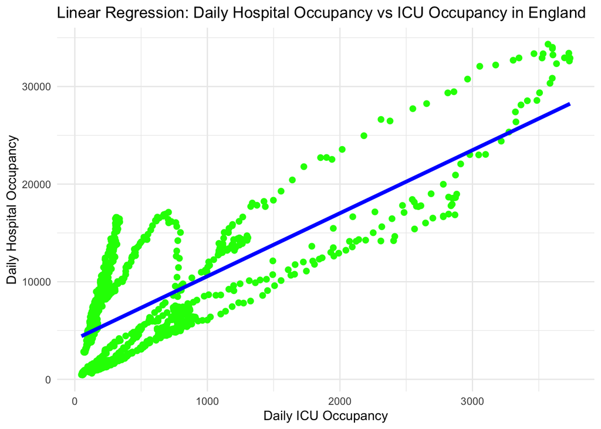

```r
# Scatter plot with regression line
ggplot(england_wide, aes(x = `Daily ICU occupancy`, y = `Daily hospital occupancy`)) +
  geom_point(aes(color = "ICU vs Hospital Occupancy"), size = 2) +  # Scatter plot
  geom_smooth(method = "lm", se = FALSE, color = "blue", linewidth = 1.5) +  # Use linewidth instead of size
  labs(title = "Linear Regression: Daily Hospital Occupancy vs ICU Occupancy in England",
       x = "Daily ICU Occupancy",
       y = "Daily Hospital Occupancy") +
  theme_minimal() +
  scale_color_manual(name = "Occupancy Type", values = c("ICU vs Hospital Occupancy" = "green")) +
  theme(legend.position = "none")
```

Here we can see a pretty good representation for Daily ICU occupancy to Daily Hospital Occupancy with this linear regression model, however we are going to try and change the colour gradient over time of the points to see if there are any points which look like they could be better represented by another regression model.

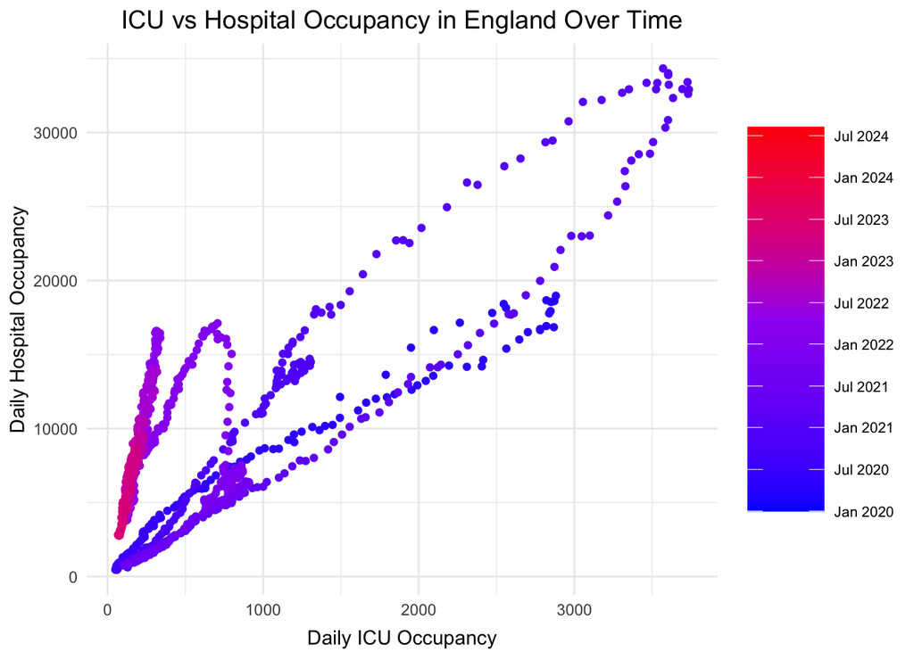

```r
# Convert date column to Date type if not already done
data$date <- as.Date(data$date)

# Filter the data for 'England' and the relevant indicators
data_filtered <- data %>%
    filter(entity == "England",
           indicator %in% c("Daily ICU occupancy", "Daily hospital occupancy")) %>%
    select(entity, date, indicator, value)

# Pivot data to wide format to have ICU and hospital occupancy in separate columns
data_wide <- data_filtered %>%
    pivot_wider(names_from = indicator, values_from = value)

# Remove rows with missing values
data_wide <- na.omit(data_wide)

# Define breaks for color gradient with more uniform distribution
breaks_dates <- seq(as.Date("2020-01-06"), as.Date("2024-08-12"), by = "6 months")

# Plot the scatter plot with color representing date
ggplot(data_wide, aes(x = `Daily ICU occupancy`, y = `Daily hospital occupancy`, color = date)) +
    geom_point() +
    scale_color_gradientn(colors = c("blue", "purple", "red"),  # Maintain original color scheme
                          limits = c(as.Date("2020-01-06"), as.Date("2024-08-12")),
                          values = scales::rescale(seq(0, 1, length.out = length(breaks_dates))),
                          name = NULL,  # Remove legend title
                          breaks = breaks_dates,
                          labels = format(breaks_dates, "%b %Y")) +
    labs(title = "ICU vs Hospital Occupancy in England Over Time",
         x = "Daily ICU Occupancy",
         y = "Daily Hospital Occupancy") +
    theme_minimal() +
    theme(axis.title.x = element_text(vjust = -0.5),  # Adjust x-axis label position
          plot.title = element_text(size = 14, hjust = 0.5),  # Center align title and adjust size
          legend.position = "right",  # Position legend on the right side
          legend.text = element_text(size = 8),  # Adjust size of the labels under the gradient scale
          legend.key.size = unit(1.5, "cm"))  # Increase the length of the color gradient legend
```

From this colour gradient, it looks like towards the back end of our data, and the start of our data, we have a better correlation. So it would better to see each of them individually. This is because one is before the vaccine, and the other is after the vaccine has taken full effect.

```r
# Convert date column to Date type if not already done
data$date <- as.Date(data$date)

# Filter the data for 'England', relevant indicators, and the first 6 months
data_filtered <- data %>%
    filter(entity == "England",
           indicator %in% c("Daily ICU occupancy", "Daily hospital occupancy"),
           date >= as.Date("2023-01-01") & date <= as.Date("2023-06-30")) %>%
    select(entity, date, indicator, value)

# Pivot data to wide format to have ICU and hospital occupancy in separate columns
data_wide <- data_filtered %>%
    pivot_wider(names_from = indicator, values_from = value)

# Remove rows with missing values
data_wide <- na.omit(data_wide)

# Perform linear regression
model <- lm(`Daily hospital occupancy` ~ `Daily ICU occupancy`, data = data_wide)

# Perform summary of the model
summary(model)
```

```
##
## Call:
## lm(formula = `Daily hospital occupancy` ~ `Daily ICU occupancy`,
##     data = data_wide)
##
## Residuals:
##      Min       1Q   Median       3Q      Max
## -1105.26  -463.47   -54.59   371.62  1349.92
##
## Coefficients:
##                       Estimate Std. Error t value Pr(>|t|)
## (Intercept)           -293.173    191.223  -1.533    0.127
## `Daily ICU occupancy`   47.121      1.319  35.715   <2e-16 ***
## ---
## Signif. codes:  0 '***' 0.001 '**' 0.01 '*' 0.05 '.' 0.1 ' ' 1
##
## Residual standard error: 570.3 on 149 degrees of freedom
## Multiple R-squared:  0.8954, Adjusted R-squared:  0.8947
## F-statistic:  1276 on 1 and 149 DF,  p-value: < 2.2e-16
```

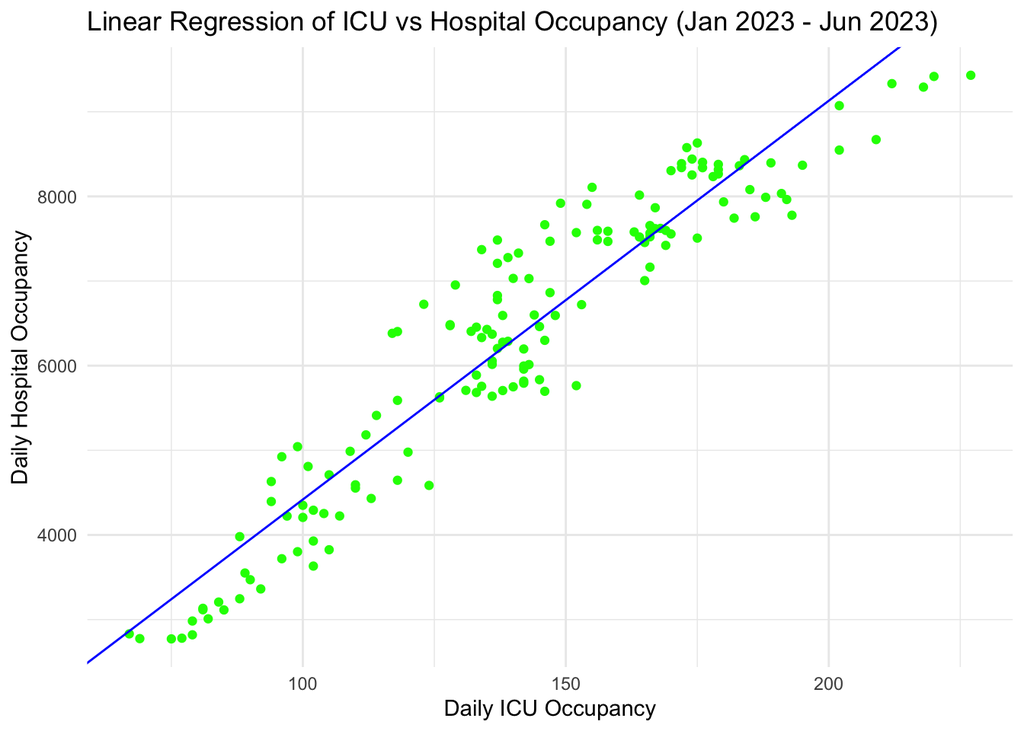

```r
# Plot the scatter plot with regression line (green dots and blue straight line)
ggplot(data_wide, aes(x = `Daily ICU occupancy`, y = `Daily hospital occupancy`)) +
    geom_point(color = "green") +  # Green dots
    geom_abline(intercept = coef(model)[1], slope = coef(model)[2], color = "blue", linetype = "solid") +  # Blue straight regression line
    labs(title = "Linear Regression of ICU vs Hospital Occupancy (Jan 2023 - Jun 2023)",
         x = "Daily ICU Occupancy",
         y = "Daily Hospital Occupancy") +
    theme_minimal()
```

From looking at this, it seems like we have a good regression model for ICU Occupancy to Hospital Occupancy from January 2023 to June 2023, after the heights of the COVID pandemic. After looking at the summary, we can see from the R-Squared that 89.54% of the variance in the dependent variable can be explained by the independent variable. This means that generally, the model fits the data well. With the F-statistic being quite high, it means the model provides a significantly better fit than a model without any predictors.

```r
# Convert date column to Date type if not already done
data$date <- as.Date(data$date)

# Filter the data for 'England', relevant indicators, and the first 6 months
data_filtered <- data %>%
    filter(entity == "England",
           indicator %in% c("Daily ICU occupancy", "Daily hospital occupancy"),
           date >= as.Date("2020-01-01") & date <= as.Date("2020-06-30")) %>%
    select(entity, date, indicator, value)

# Pivot data to wide format to have ICU and hospital occupancy in separate columns
data_wide <- data_filtered %>%
    pivot_wider(names_from = indicator, values_from = value)

# Remove rows with missing values
data_wide <- na.omit(data_wide)

# Perform linear regression
model <- lm(`Daily hospital occupancy` ~ `Daily ICU occupancy`, data = data_wide)

# Perform summary of the model
summary(model)
```

```
##
## Call:
## lm(formula = `Daily hospital occupancy` ~ `Daily ICU occupancy`,
##     data = data_wide)
##
## Residuals:
##      Min       1Q   Median       3Q      Max
## -1617.82  -549.27   -30.12   433.93  2560.65
##
## Coefficients:
##                        Estimate Std. Error t value Pr(>|t|)
## (Intercept)           2.362e+03  1.489e+02   15.87   <2e-16 ***
## `Daily ICU occupancy` 5.596e+00  9.288e-02   60.25   <2e-16 ***
## ---
## Signif. codes:  0 '***' 0.001 '**' 0.01 '*' 0.05 '.' 0.1 ' ' 1
##
## Residual standard error: 815.4 on 88 degrees of freedom
## Multiple R-squared:  0.9763, Adjusted R-squared:  0.9761
## F-statistic:  3630 on 1 and 88 DF,  p-value: < 2.2e-16
```

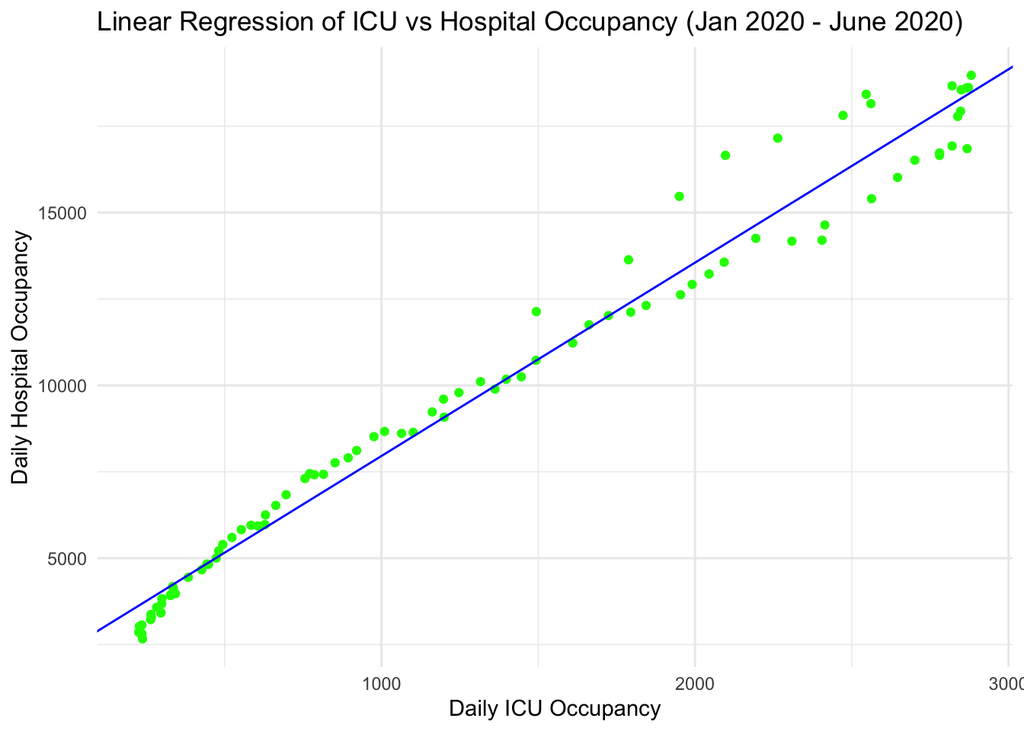

```r
# Plot the scatter plot with regression line (green dots and blue straight line)
ggplot(data_wide, aes(x = `Daily ICU occupancy`, y = `Daily hospital occupancy`)) +
    geom_point(color = "green") +  # Green dots
    geom_abline(intercept = coef(model)[1], slope = coef(model)[2], color = "blue", linetype = "solid") +  # Blue straight regression line
    labs(title = "Linear Regression of ICU vs Hospital Occupancy (Jan 2020 - June 2020)",
         x = "Daily ICU Occupancy",
         y = "Daily Hospital Occupancy") +
    theme_minimal()
```